# **Step 1: Data Understanding**

## **Step 2. EDA**

### Step 2.1. Univariate Analysis

#### 2.1.1. Categorical Variables

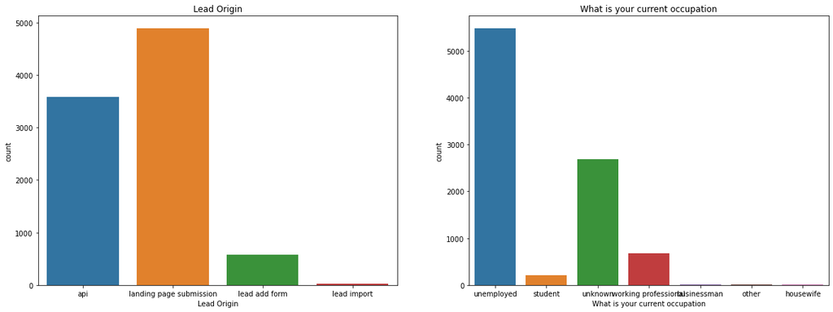

```python
#Plotting all category variables

plt.figure(figsize = (20,7))

eda_uni_cols=list(lead_df.select_dtypes('object').columns)
removelist=['Do Not Email', 'Do Not Call', 'Search', 'Newspaper Article', 'X Education Forums', 'Newspaper', 'Digital Advertisement', 'Through Recommendations', 'A free copy of Mastering The Interview','Lead Source','Last Activity','Specialization','Last Notable Activity']

# removing columns those are in the e as well as eda_uni_cols list from the eda_uni_cols list
for e in removelist:
    if e in (eda_uni_cols):
        eda_uni_cols.remove(e)

for i in range(len(eda_uni_cols)):
    plt.subplot(1,2,i+1) # subplot of 1 x 2
    sns.countplot(lead_df[eda_uni_cols[i]]) # ploting the count plot of vaiables
    plt.title(eda_uni_cols[i]) # printing the title of graph
```

### **Observation:**

- X Education recived, mostly the lead of customer from api and landing page submission
- In the second graph, the custers of x Education are unemployeed and unworking

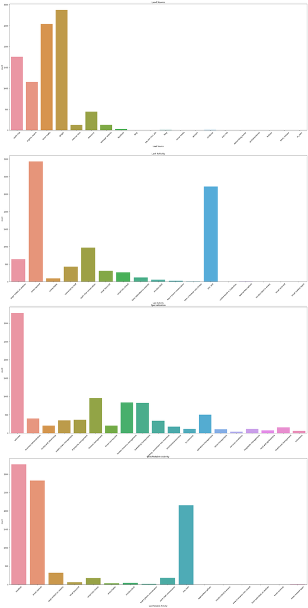

```python
plt.figure(figsize = (30,60))

eda_uni_cols=list(['Lead Source','Last Activity','Specialization','Last Notable Activity']) # the list of columns

for i in range(len(eda_uni_cols)):
    plt.subplot(4,1,i+1) # subplot of 4 x 1
    sns.countplot(lead_df[eda_uni_cols[i]]).tick_params(axis='x', rotation = 45) # ploting the count plot of variables
    plt.title(eda_uni_cols[i]) # tittle of the plot
```

### **Observation:**

- In the first plot, it shows that the higest lead source are visiting the X Education from the "Google" and "direct Traffic".
- In the second plot, it shows that the higest lead are activated at the email or sms.
- In the third plot, it shows that the higest lead specilization are unknown. That means lead havent provided thire interested specilization.
- In the fourth plot, it shows that the higest lead last notable activity are modified,email opend and sms sent.

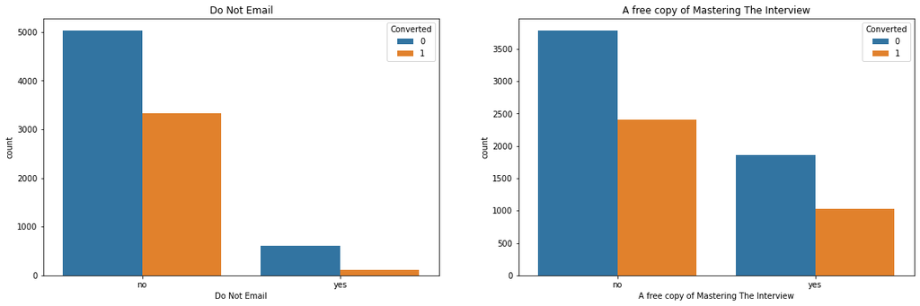

```python
c = list(lead_df.select_dtypes('object').columns)              # extracting only object data type variable and storing them into c class variable
new_list = []                                                  # defined new list
for i in range(len(c)):
    if len((lead_df[c[i]].value_counts().index)) == 2:         # checking the columns those index are equal to the two
        new_list.append(c[i])                                  # Storing the columns name into the new list

plt.figure(figsize=(30,20))                                    # defined the figure size

for i in range(len(new_list)):
    plt.subplot(3,3,i+1)                                       # subplot of 5 x 2
    sns.countplot(x=new_list[i],data=lead_df,hue='Converted')  # ploting the count plot of variables
    plt.title(new_list[i])                                     # define the title of plot
plt.show()
```

### **Observation:**

- In the first graph, it shows that most customer wants to recived the email from the x education Company. Also those custemer recived the email are more converted.
- In the first graph, it shows that most customer not wants to recived the A free copy of mastering the interview from the x education Company.

#### 2.1.2. Numerical Variables

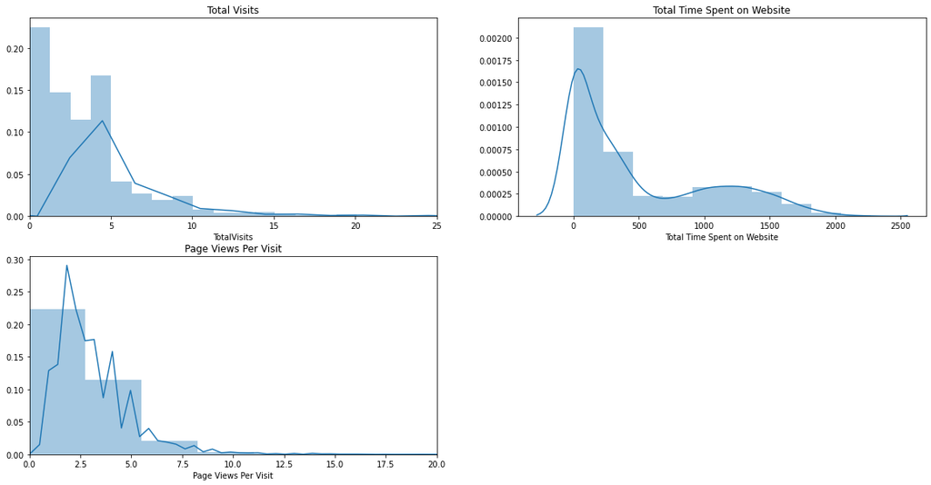

```python
plt.figure(figsize = (20,10))
plt.subplot(2,2,1)
sns.distplot(lead_df['TotalVisits'], bins = 200)
plt.title('Total Visits')
plt.xlim(0,25)

plt.subplot(2,2,2)
sns.distplot(lead_df['Total Time Spent on Website'], bins = 10)
plt.title('Total Time Spent on Website')

plt.subplot(2,2,3)
sns.distplot(lead_df['Page Views Per Visit'], bins = 20)
plt.title('Page Views Per Visit')
plt.xlim(0,20)
plt.show()
```

#### 2.1.3. Checking Lead variables against converted target variable

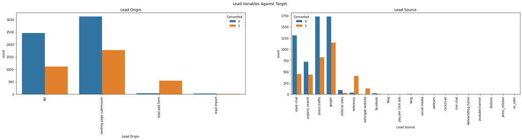

```python
plt.figure(figsize=(30,5))
plt.suptitle("Lead Variables Against Target")
plt.subplot(1,2,1)
sns.countplot(x='Lead Origin',hue='Converted',data=lead_df).tick_params(axis='x',rotation=90)
plt.title('Lead Origin')

plt.subplot(1,2,2)
sns.countplot(x='Lead Source',hue='Converted',data=lead_df).tick_params(axis='x',rotation = 90)
plt.title('Lead Source')
plt.show()
```

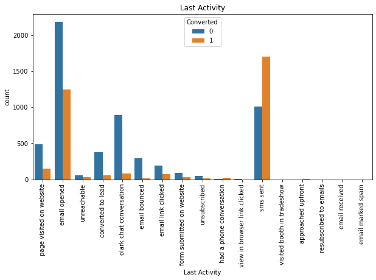

```python
plt.figure(figsize = (10,5))

sns.countplot(x='Last Activity', hue='Converted', data= lead_df).tick_params(axis='x', rotation = 90)
plt.title('Last Activity')
plt.show()
```

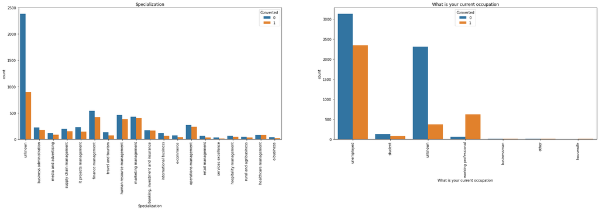

```python
plt.figure(figsize = (30,7))

plt.subplot(1,2,1)
sns.countplot(x='Specialization', hue='Converted', data= lead_df).tick_params(axis='x', rotation = 90)
plt.title('Specialization')

plt.subplot(1,2,2)
sns.countplot(x='What is your current occupation', hue='Converted', data= lead_df).tick_params(axis='x', rotation = 90)
plt.title('What is your current occupation')
plt.show()
```

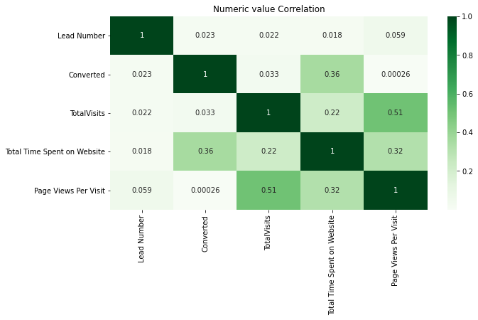

```python
#Numeric Value correlation
plt.figure(figsize=[10,5])
plt.title("Numeric value Correlation")
sns.heatmap(lead_df.corr(),annot=True,cmap="Greens")
plt.show()
```

## Step 3: Outlier Treatment

```python
# cheking the outliers of only numeric values variables
numeric = lead_df[['TotalVisits','Total Time Spent on Website','Page Views Per Visit']]
# describing the variables in following percentiles
numeric.describe(percentiles=[0.25,0.5,0.75,0.9,0.99])
```

|  | TotalVisits | Total Time Spent on Website | Page Views Per Visit |
| --- | --- | --- | --- |
| count | 9074.000000 | 9074.000000 | 9074.000000 |
| mean | 3.456028 | 482.887481 | 2.370151 |
| std | 4.858802 | 545.256560 | 2.160871 |
| min | 0.000000 | 0.000000 | 0.000000 |
| 25% | 1.000000 | 11.000000 | 1.000000 |
| 50% | 3.000000 | 246.000000 | 2.000000 |
| 75% | 5.000000 | 922.750000 | 3.200000 |
| 90% | 7.000000 | 1373.000000 | 5.000000 |
| 99% | 17.000000 | 1839.000000 | 9.000000 |
| max | 251.000000 | 2272.000000 | 55.000000 |

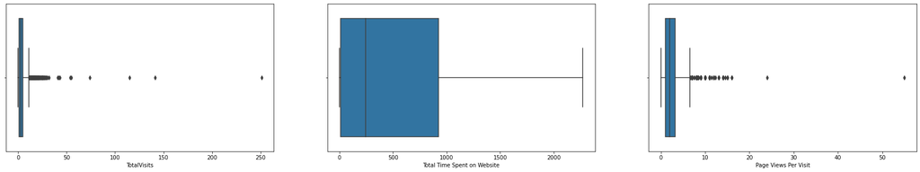

```python
# Graphical view of the outliers

cols=['TotalVisits','Total Time Spent on Website','Page Views Per Visit'] # list of columns

plt.figure(figsize = (30,5))

plt.subplot(1,3,1)
sns.boxplot(lead_df['TotalVisits'])
plt.subplot(1,3,2)
sns.boxplot(lead_df['Total Time Spent on Website'])
plt.subplot(1,3,3)
sns.boxplot(lead_df['Page Views Per Visit'] )

plt.show()
```

## Retaining 99% quantile of data

```python
outlier_cap_percent =.99 # define the cap of percentiles

# applying the treatment
for c in cols:
    lead_df=lead_df[lead_df[c] <= lead_df[c].quantile(outlier_cap_percent)]
```

## Step 4. Dummy Variables

Identifying all categorical variables

```python
# storing the variable, those data type is object
dummy_cols=lead_df.loc[:, lead_df.dtypes == 'object'].columns
```

```python
# Create dummy variables using the 'get_dummies function and storing into the dummy datafram
dummy = pd.get_dummies(lead_df[dummy_cols], drop_first=True)

# merege the results to the final dataframe
lead_df_dum = pd.concat([lead_df, dummy], axis=1)
```

```python
#dropping repeating columns
lead_df_dum.drop(dummy_cols, 1, inplace = True) # Dropping the dummy variables
# Dropping the not usable columns
lead_df_dum.drop(['What is your current occupation_unknown','Specialization_unknown'],axis=1,inplace=True)
lead_df_dum.head()
```

|  | Lead Number | Converted | TotalVisits | Total Time Spent on Website | Page Views Per Visit | Lead Origin_landing page submission | Lead Origin_lead add form | Lead Origin_lead import | Lead Source_blog | Lead Source_click2call | ... | Last Notable Activity_form submitted on website | Last Notable Activity_had a phone conversation | Last Notable Activity_modified | Last Notable Activity_olark chat conversation | Last Notable Activity_page visited on website | Last Notable Activity_resubscribed to emails | Last Notable Activity_sms sent | Last Notable Activity_unreachable | Last Notable Activity_unsubscribed | Last Notable Activity_view in browser link clicked |
| --- | --- | --- | --- | --- | --- | --- | --- | --- | --- | --- | --- | --- | --- | --- | --- | --- | --- | --- | --- | --- | --- |
| 0 | 660737 | 0 | 0.0 | 0 | 0.0 | 0 | 0 | 0 | 0 | 0 | ... | 0 | 0 | 1 | 0 | 0 | 0 | 0 | 0 | 0 | 0 |
| 1 | 660728 | 0 | 5.0 | 674 | 2.5 | 0 | 0 | 0 | 0 | 0 | ... | 0 | 0 | 0 | 0 | 0 | 0 | 0 | 0 | 0 | 0 |
| 2 | 660727 | 1 | 2.0 | 1532 | 2.0 | 1 | 0 | 0 | 0 | 0 | ... | 0 | 0 | 0 | 0 | 0 | 0 | 0 | 0 | 0 | 0 |
| 3 | 660719 | 0 | 1.0 | 305 | 1.0 | 1 | 0 | 0 | 0 | 0 | ... | 0 | 0 | 1 | 0 | 0 | 0 | 0 | 0 | 0 | 0 |
| 4 | 660681 | 1 | 2.0 | 1428 | 1.0 | 1 | 0 | 0 | 0 | 0 | ... | 0 | 0 | 1 | 0 | 0 | 0 | 0 | 0 | 0 | 0 |

5 rows × 82 columns

```python
# Cheking the dataframe info
lead_df_dum.info()
```

```
<class 'pandas.core.frame.DataFrame'>
Int64Index: 8834 entries, 0 to 9239
Data columns (total 82 columns):
 #   Column                                                Non-Null Count  Dtype
---  ------                                                --------------  -----
 0   Lead Number                                           8834 non-null   int64
 1   Converted                                             8834 non-null   int64
 2   TotalVisits                                           8834 non-null   float64
 3   Total Time Spent on Website                           8834 non-null   int64
 4   Page Views Per Visit                                  8834 non-null   float64
 5   Lead Origin_landing page submission                   8834 non-null   uint8
 6   Lead Origin_lead add form                             8834 non-null   uint8
 7   Lead Origin_lead import                               8834 non-null   uint8
 8   Lead Source_blog                                      8834 non-null   uint8
 9   Lead Source_click2call                                8834 non-null   uint8
```

[output cut: 74 more lines]

## 4. Test-Train Split

```python
# Import the required library
from sklearn.model_selection import train_test_split
```

```python
# dropping the target variable and unique id of the lead
X = lead_df_dum.drop(['Converted','Lead Number'], 1) # storing the dataframe into the X
X.head()
```

|  | TotalVisits | Total Time Spent on Website | Page Views Per Visit | Lead Origin_landing page submission | Lead Origin_lead add form | Lead Origin_lead import | Lead Source_blog | Lead Source_click2call | Lead Source_direct traffic | Lead Source_facebook | ... | Last Notable Activity_form submitted on website | Last Notable Activity_had a phone conversation | Last Notable Activity_modified | Last Notable Activity_olark chat conversation | Last Notable Activity_page visited on website | Last Notable Activity_resubscribed to emails | Last Notable Activity_sms sent | Last Notable Activity_unreachable | Last Notable Activity_unsubscribed | Last Notable Activity_view in browser link clicked |
| --- | --- | --- | --- | --- | --- | --- | --- | --- | --- | --- | --- | --- | --- | --- | --- | --- | --- | --- | --- | --- | --- |
| 0 | 0.0 | 0 | 0.0 | 0 | 0 | 0 | 0 | 0 | 0 | 0 | ... | 0 | 0 | 1 | 0 | 0 | 0 | 0 | 0 | 0 | 0 |
| 1 | 5.0 | 674 | 2.5 | 0 | 0 | 0 | 0 | 0 | 0 | 0 | ... | 0 | 0 | 0 | 0 | 0 | 0 | 0 | 0 | 0 | 0 |
| 2 | 2.0 | 1532 | 2.0 | 1 | 0 | 0 | 0 | 0 | 1 | 0 | ... | 0 | 0 | 0 | 0 | 0 | 0 | 0 | 0 | 0 | 0 |
| 3 | 1.0 | 305 | 1.0 | 1 | 0 | 0 | 0 | 0 | 1 | 0 | ... | 0 | 0 | 1 | 0 | 0 | 0 | 0 | 0 | 0 | 0 |
| 4 | 2.0 | 1428 | 1.0 | 1 | 0 | 0 | 0 | 0 | 0 | 0 | ... | 0 | 0 | 1 | 0 | 0 | 0 | 0 | 0 | 0 | 0 |

5 rows × 80 columns

```python
# Putting the target variable in y
y = lead_df_dum['Converted']
y.head()
```

```
0    0
1    0
2    1
3    0
4    1
Name: Converted, dtype: int64
```

```python
# Split the dataset into 70% and 30% for train and test respectively
X_train, X_test, y_train, y_test = train_test_split(
    X, y, train_size=0.7, test_size=0.3, random_state=10)
```

```python
# Import MinMaxscaler
from sklearn.preprocessing import MinMaxScaler
# Scale the numeric features
scaler = MinMaxScaler()
X_train[['TotalVisits', 'Page Views Per Visit', 'Total Time Spent on Website']] = scaler.fit_transform(X_train[['TotalVisits', 'Page Views Per Visit', 'Total Time Spent on Website']])
X_train.head()
```

|  | TotalVisits | Total Time Spent on Website | Page Views Per Visit | Lead Origin_landing page submission | Lead Origin_lead add form | Lead Origin_lead import | Lead Source_blog | Lead Source_click2call | Lead Source_direct traffic | Lead Source_facebook | ... | Last Notable Activity_form submitted on website | Last Notable Activity_had a phone conversation | Last Notable Activity_modified | Last Notable Activity_olark chat conversation | Last Notable Activity_page visited on website | Last Notable Activity_resubscribed to emails | Last Notable Activity_sms sent | Last Notable Activity_unreachable | Last Notable Activity_unsubscribed | Last Notable Activity_view in browser link clicked |
| --- | --- | --- | --- | --- | --- | --- | --- | --- | --- | --- | --- | --- | --- | --- | --- | --- | --- | --- | --- | --- | --- |
| 148 | 0.294118 | 0.126293 | 0.277778 | 1 | 0 | 0 | 0 | 0 | 0 | 0 | ... | 0 | 0 | 0 | 0 | 0 | 0 | 0 | 0 | 0 | 0 |
| 9165 | 0.000000 | 0.000000 | 0.000000 | 0 | 0 | 0 | 0 | 0 | 0 | 0 | ... | 0 | 0 | 1 | 0 | 0 | 0 | 0 | 0 | 0 | 0 |
| 1436 | 0.235294 | 0.918889 | 0.444444 | 1 | 0 | 0 | 0 | 0 | 0 | 0 | ... | 0 | 0 | 0 | 0 | 0 | 0 | 0 | 0 | 0 | 0 |
| 8693 | 0.117647 | 0.188351 | 0.222222 | 1 | 0 | 0 | 0 | 0 | 1 | 0 | ... | 0 | 0 | 1 | 0 | 0 | 0 | 0 | 0 | 0 | 0 |
| 317 | 0.588235 | 0.302667 | 0.555556 | 0 | 0 | 0 | 0 | 0 | 0 | 0 | ... | 0 | 0 | 1 | 0 | 0 | 0 | 0 | 0 | 0 | 0 |

5 rows × 80 columns

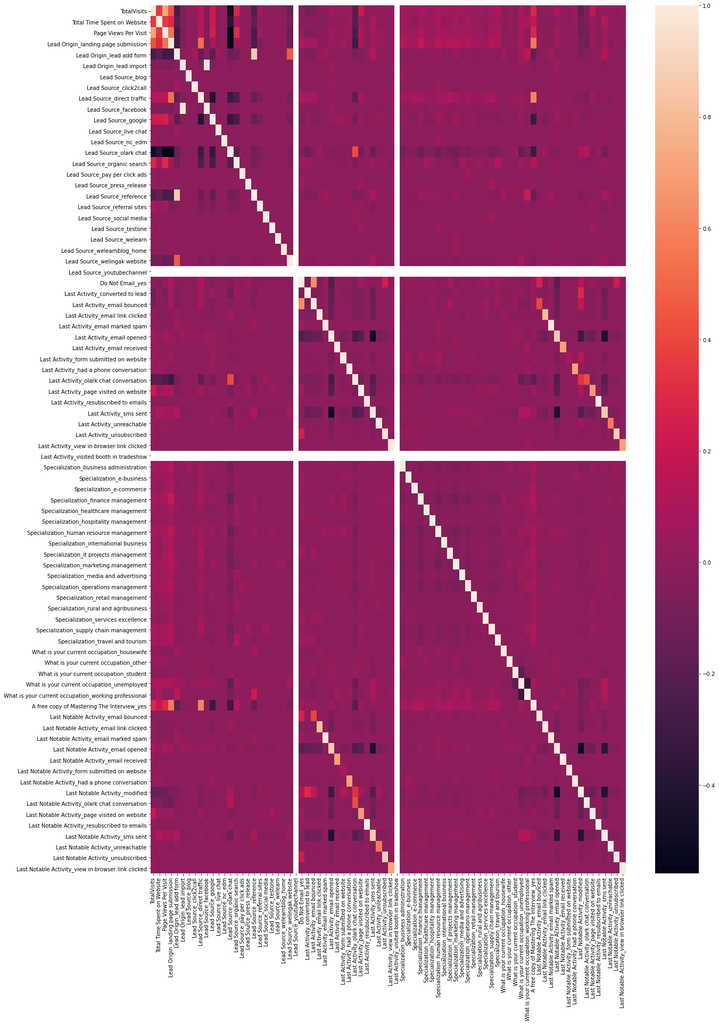

```python
# To check the correlation among varibles
plt.figure(figsize=(20,30))
sns.heatmap(X_train.corr())
plt.show()
```

### Observation:

- Its not easy to determine the correlation using above heatmap. Hence we are using RFE to determine the columns to be considered for the model.

## 5. Model Building

```python
# Import 'LogisticRegression'
from sklearn.linear_model import LogisticRegression
logreg = LogisticRegression()
```

```python
# Import RFE
from sklearn.feature_selection import RFE
```

```python
# Running RFE with 15 variables as output
rfe = RFE(logreg, 15)
# applying the fit on the x and y train dataframe
rfe = rfe.fit(X_train, y_train)
```

```python
# Features that have been selected by RFE
list(zip(X_train.columns, rfe.support_, rfe.ranking_))
```

```
[('TotalVisits', True, 1),
 ('Total Time Spent on Website', True, 1),
 ('Page Views Per Visit', False, 10),
 ('Lead Origin_landing page submission', False, 31),
 ('Lead Origin_lead add form', True, 1),
 ('Lead Origin_lead import', False, 45),
 ('Lead Source_blog', False, 53),
 ('Lead Source_click2call', False, 27),
 ('Lead Source_direct traffic', True, 1),
 ('Lead Source_facebook', False, 52),
 ('Lead Source_google', True, 1),
 ('Lead Source_live chat', False, 56),
 ('Lead Source_nc_edm', False, 23),
 ('Lead Source_olark chat', False, 20),
 ('Lead Source_organic search', True, 1),
 ('Lead Source_pay per click ads', False, 50),
 ('Lead Source_press_release', False, 62),
 ('Lead Source_reference', False, 18),
 ('Lead Source_referral sites', True, 1),
 ('Lead Source_social media', False, 19),
 ('Lead Source_testone', False, 37),
 ('Lead Source_welearn', False, 51),
 ('Lead Source_welearnblog_home', False, 54),
 ('Lead Source_welingak website', True, 1),
 ('Lead Source_youtubechannel', False, 66),
 ('Do Not Email_yes', True, 1),
 ('Last Activity_converted to lead', False, 36),
 ('Last Activity_email bounced', False, 40),
 ('Last Activity_email link clicked', False, 43),
 ('Last Activity_email marked spam', False, 48),
 ('Last Activity_email opened', False, 6),
 ('Last Activity_email received', False, 60),
 ('Last Activity_form submitted on website', False, 26),
 ('Last Activity_had a phone conversation', True, 1),
 ('Last Activity_olark chat conversation', False, 15),
 ('Last Activity_page visited on website', False, 42),
 ('Last Activity_resubscribed to emails', False, 12),
 ('Last Activity_sms sent', True, 1),
 ('Last Activity_unreachable', False, 41),
 ('Last Activity_unsubscribed', False, 9),
```

[output cut: 25 more lines]

```
 ('Last Notable Activity_email bounced', False, 39),
 ('Last Notable Activity_email link clicked', False, 17),
 ('Last Notable Activity_email marked spam', False, 44),
 ('Last Notable Activity_email opened', False, 7),
 ('Last Notable Activity_email received', False, 63),
 ('Last Notable Activity_form submitted on website', False, 64),
 ('Last Notable Activity_had a phone conversation', False, 8),
 ('Last Notable Activity_modified', False, 5),
 ('Last Notable Activity_olark chat conversation', True, 1),
 ('Last Notable Activity_page visited on website', False, 16),
 ('Last Notable Activity_resubscribed to emails', False, 11),
 ('Last Notable Activity_sms sent', False, 38),
 ('Last Notable Activity_unreachable', True, 1),
 ('Last Notable Activity_unsubscribed', False, 61),
 ('Last Notable Activity_view in browser link clicked', False, 46)]
```

```python
# Put all the columns selected by RFE in the variable 'col'
col = X_train.columns[rfe.support_]
```

```python
col
```

```
Index(['TotalVisits', 'Total Time Spent on Website',
       'Lead Origin_lead add form', 'Lead Source_direct traffic',
       'Lead Source_google', 'Lead Source_organic search',
       'Lead Source_referral sites', 'Lead Source_welingak website',
       'Do Not Email_yes', 'Last Activity_had a phone conversation',
       'Last Activity_sms sent', 'What is your current occupation_housewife',
       'What is your current occupation_working professional',
       'Last Notable Activity_olark chat conversation',
       'Last Notable Activity_unreachable'],
      dtype='object')
```

```python
# Selecting columns selected by RFE
X_train = X_train[col]
```

```python
# Importing statsmodels
import statsmodels.api as sm
```

```python
# Importing 'variance_inflation_factor'
from statsmodels.stats.outliers_influence import variance_inflation_factor
```

```python
# Make a VIF dataframe for all the variables present.
# Creating the function of the VIF to called multiple time
def vif_():
    vif = pd.DataFrame()
    vif['Features'] = X_train.columns
    vif['VIF'] = [variance_inflation_factor(X_train.values, i) for i in range(X_train.shape[1])]
    vif['VIF'] = round(vif['VIF'], 2)
    vif = vif.sort_values(by = "VIF", ascending = False)
    return vif
```

## **5.1 Model One**

```python
X_train_sm = sm.add_constant(X_train)                                   # adding the constant
logm1 = sm.GLM(y_train, X_train_sm, family = sm.families.Binomial())    # applying the GLM modeling
res = logm1.fit()                                                       # apply the fit on the model
print(res.summary())                                                    # printing the summary of model
print(vif_())                                                           # printing the VIF of model
```

```
                 Generalized Linear Model Regression Results
==============================================================================
Dep. Variable:              Converted   No. Observations:                 6183
Model:                            GLM   Df Residuals:                     6167
Model Family:                Binomial   Df Model:                           15
Link Function:                  logit   Scale:                          1.0000
Method:                          IRLS   Log-Likelihood:                -2687.1
Date:                Sun, 07 Feb 2021   Deviance:                       5374.1
Time:                        15:50:35   Pearson chi2:                 6.23e+03
No. Iterations:                    21
Covariance Type:            nonrobust
========================================================================================================================
                                                           coef    std err          z      P>|z|      [0.025      0.975]
------------------------------------------------------------------------------------------------------------------------
const                                                   -1.6027      0.077    -20.946      0.000      -1.753      -1.453
TotalVisits                                              1.5622      0.248      6.311      0.000       1.077       2.047
Total Time Spent on Website                              3.8290      0.139     27.616      0.000       3.557       4.101
Lead Origin_lead add form                                2.7980      0.217     12.912      0.000       2.373       3.223
Lead Source_direct traffic                              -1.4971      0.123    -12.147      0.000      -1.739      -1.256
Lead Source_google                                      -1.2003      0.119    -10.084      0.000      -1.434      -0.967
Lead Source_organic search                              -1.4438      0.150     -9.627      0.000      -1.738      -1.150
Lead Source_referral sites                              -1.5161      0.353     -4.291      0.000      -2.209      -0.824
Lead Source_welingak website                             1.9542      0.748      2.614      0.009       0.489       3.420
Do Not Email_yes                                        -1.4212      0.171     -8.321      0.000      -1.756      -1.086
Last Activity_had a phone conversation                   1.8766      0.636      2.953      0.003       0.631       3.122
Last Activity_sms sent                                   1.4912      0.074     20.246      0.000       1.347       1.636
What is your current occupation_housewife               23.3804   1.77e+04      0.001      0.999   -3.47e+04    3.47e+04
What is your current occupation_working professional     2.8212      0.187     15.067      0.000       2.454       3.188
Last Notable Activity_olark chat conversation           -1.4137      0.360     -3.932      0.000      -2.118      -0.709
Last Notable Activity_unreachable                        1.4369      0.535      2.686      0.007       0.388       2.486
========================================================================================================================
                                             Features   VIF
0                                         TotalVisits  3.49
4                                  Lead Source_google  2.54
1                         Total Time Spent on Website  2.36
3                          Lead Source_direct traffic  2.24
5                          Lead Source_organic search  1.88
2                           Lead Origin_lead add form  1.48
10                             Last Activity_sms sent  1.47
7                        Lead Source_welingak website  1.32
12  What is your current occupation_working profes...  1.16
8                                    Do Not Email_yes  1.11
6                          Lead Source_referral sites  1.07
9              Last Activity_had a phone conversation  1.01
11          What is your current occupation_housewife  1.01
13      Last Notable Activity_olark chat conversation  1.01
14                  Last Notable Activity_unreachable  1.01
```

**The vif of "What is your current occupation_housewife" variable is good but the "P value" is greater than the 0.05. Due to this we are dropping this variable from the model**

```python
# dropping the variable
X_train.drop('What is your current occupation_housewife', axis = 1, inplace = True)
```

## **5.2 Model Two**

```python
X_train_sm = sm.add_constant(X_train)                                   # adding the constant
logm2 = sm.GLM(y_train, X_train_sm, family = sm.families.Binomial())    # applying the GLM modeling
res = logm2.fit()                                                       # apply the fit on the model
print(res.summary())                                                    # printing the summary of model
print(vif_())                                                           # printing the VIF of model
```

```
                 Generalized Linear Model Regression Results
==============================================================================
Dep. Variable:              Converted   No. Observations:                 6183
Model:                            GLM   Df Residuals:                     6168
Model Family:                Binomial   Df Model:                           14
Link Function:                  logit   Scale:                          1.0000
Method:                          IRLS   Log-Likelihood:                -2690.9
Date:                Sun, 07 Feb 2021   Deviance:                       5381.9
Time:                        15:50:35   Pearson chi2:                 6.24e+03
No. Iterations:                     7
Covariance Type:            nonrobust
========================================================================================================================
                                                           coef    std err          z      P>|z|      [0.025      0.975]
------------------------------------------------------------------------------------------------------------------------
const                                                   -1.6010      0.076    -20.934      0.000      -1.751      -1.451
TotalVisits                                              1.5536      0.247      6.280      0.000       1.069       2.039
Total Time Spent on Website                              3.8242      0.138     27.615      0.000       3.553       4.096
Lead Origin_lead add form                                2.8248      0.216     13.062      0.000       2.401       3.249
Lead Source_direct traffic                              -1.4931      0.123    -12.124      0.000      -1.734      -1.252
Lead Source_google                                      -1.1954      0.119    -10.051      0.000      -1.429      -0.962
Lead Source_organic search                              -1.4305      0.150     -9.554      0.000      -1.724      -1.137
Lead Source_referral sites                              -1.5125      0.353     -4.283      0.000      -2.205      -0.820
Lead Source_welingak website                             1.9277      0.748      2.578      0.010       0.462       3.393
Do Not Email_yes                                        -1.4235      0.171     -8.334      0.000      -1.758      -1.089
Last Activity_had a phone conversation                   1.8718      0.636      2.945      0.003       0.626       3.118
Last Activity_sms sent                                   1.4872      0.074     20.202      0.000       1.343       1.631
What is your current occupation_working professional     2.8179      0.187     15.052      0.000       2.451       3.185
Last Notable Activity_olark chat conversation           -1.4148      0.359     -3.936      0.000      -2.119      -0.710
Last Notable Activity_unreachable                        1.4321      0.535      2.676      0.007       0.383       2.481
========================================================================================================================
                                             Features   VIF
0                                         TotalVisits  3.49
4                                  Lead Source_google  2.54
1                         Total Time Spent on Website  2.36
3                          Lead Source_direct traffic  2.24
5                          Lead Source_organic search  1.87
2                           Lead Origin_lead add form  1.47
10                             Last Activity_sms sent  1.47
7                        Lead Source_welingak website  1.32
11  What is your current occupation_working profes...  1.16
8                                    Do Not Email_yes  1.11
6                          Lead Source_referral sites  1.07
9              Last Activity_had a phone conversation  1.01
12      Last Notable Activity_olark chat conversation  1.01
13                  Last Notable Activity_unreachable  1.01
```

```python
# Dropping the variable
X_train.drop('TotalVisits', axis = 1, inplace = True)
```

## **5.3 Model Three**

```python
X_train_sm = sm.add_constant(X_train)                                   # adding the constant
logm3 = sm.GLM(y_train, X_train_sm, family = sm.families.Binomial())    # applying the GLM modeling
res = logm3.fit()                                                       # apply the fit on the model
print(res.summary())                                                    # printing the summary of model
print(vif_())                                                           # printing the VIF of model
```

```
                 Generalized Linear Model Regression Results
==============================================================================
Dep. Variable:              Converted   No. Observations:                 6183
Model:                            GLM   Df Residuals:                     6169
Model Family:                Binomial   Df Model:                           13
Link Function:                  logit   Scale:                          1.0000
Method:                          IRLS   Log-Likelihood:                -2710.7
Date:                Sun, 07 Feb 2021   Deviance:                       5421.5
Time:                        15:50:36   Pearson chi2:                 6.26e+03
No. Iterations:                     7
Covariance Type:            nonrobust
========================================================================================================================
                                                           coef    std err          z      P>|z|      [0.025      0.975]
------------------------------------------------------------------------------------------------------------------------
const                                                   -1.5601      0.075    -20.671      0.000      -1.708      -1.412
Total Time Spent on Website                              3.8775      0.138     28.098      0.000       3.607       4.148
Lead Origin_lead add form                                2.7917      0.216     12.945      0.000       2.369       3.214
Lead Source_direct traffic                              -1.1842      0.110    -10.722      0.000      -1.401      -0.968
Lead Source_google                                      -0.8715      0.105     -8.312      0.000      -1.077      -0.666
Lead Source_organic search                              -0.9885      0.130     -7.632      0.000      -1.242      -0.735
Lead Source_referral sites                              -1.0961      0.347     -3.162      0.002      -1.775      -0.417
Lead Source_welingak website                             1.9353      0.747      2.589      0.010       0.470       3.400
Do Not Email_yes                                        -1.4522      0.170     -8.547      0.000      -1.785      -1.119
Last Activity_had a phone conversation                   1.9276      0.641      3.007      0.003       0.671       3.184
Last Activity_sms sent                                   1.4687      0.073     20.038      0.000       1.325       1.612
What is your current occupation_working professional     2.8128      0.186     15.095      0.000       2.448       3.178
Last Notable Activity_olark chat conversation           -1.3440      0.352     -3.824      0.000      -2.033      -0.655
Last Notable Activity_unreachable                        1.4987      0.545      2.751      0.006       0.431       2.566
========================================================================================================================
                                             Features   VIF
0                         Total Time Spent on Website  2.33
3                                  Lead Source_google  1.70
2                          Lead Source_direct traffic  1.61
1                           Lead Origin_lead add form  1.47
9                              Last Activity_sms sent  1.47
6                        Lead Source_welingak website  1.32
4                          Lead Source_organic search  1.28
10  What is your current occupation_working profes...  1.16
7                                    Do Not Email_yes  1.10
5                          Lead Source_referral sites  1.02
8              Last Activity_had a phone conversation  1.01
11      Last Notable Activity_olark chat conversation  1.01
12                  Last Notable Activity_unreachable  1.01
```

## Observation:

### **All the VIF values are good and all the p-values are below 0.05. It is, therfore, the model three is our final model.**

## Step 6. Creating Prediction

```python
# Predicting the probabilities on the train set
y_train_pred = res.predict(X_train_sm)
y_train_pred[:10]
```

```
148     0.125434
9165    0.477172
1436    0.980999
8693    0.117742
317     0.221307
8125    0.176069
4824    0.718703
1036    0.096437
1152    0.512648
5087    0.774091
dtype: float64
```

```python
# Reshaping to an array
y_train_pred = y_train_pred.values.reshape(-1)
y_train_pred[:10]
```

```
array([0.12543384, 0.47717202, 0.98099928, 0.11774176, 0.22130714,
       0.17606863, 0.71870326, 0.09643707, 0.51264791, 0.77409099])
```

```python
# Data frame with given convertion rate and probablity of predicted ones
y_train_pred_final = pd.DataFrame({'Converted':y_train.values, 'Convert_Prob':y_train_pred})
y_train_pred_final.head()
```

|  | Converted | Convert_Prob |
| --- | --- | --- |
| 0 | 0 | 0.125434 |
| 1 | 1 | 0.477172 |
| 2 | 1 | 0.980999 |
| 3 | 0 | 0.117742 |
| 4 | 1 | 0.221307 |

```python
# Substituting 0 or 1 with the cut off as 0.8
y_train_pred_final['Predicted'] = y_train_pred_final.Convert_Prob.map(lambda x: 1 if x > 0.8 else 0)
y_train_pred_final.head()
```

|  | Converted | Convert_Prob | Predicted |
| --- | --- | --- | --- |
| 0 | 0 | 0.125434 | 0 |
| 1 | 1 | 0.477172 | 0 |
| 2 | 1 | 0.980999 | 1 |
| 3 | 0 | 0.117742 | 0 |
| 4 | 1 | 0.221307 | 0 |

## Step 7. Model Evaluation

```python
# Importing metrics from sklearn for evaluation
from sklearn import metrics
```

```python
# Creating confusion matrix
confusion = metrics.confusion_matrix(y_train_pred_final.Converted, y_train_pred_final.Predicted )
confusion
```

```
array([[3759,  105],
       [1488,  831]], dtype=int64)
```

```python
# Check the overall accuracy
metrics.accuracy_score(y_train_pred_final.Converted, y_train_pred_final.Predicted)
```

```
0.74235807860262
```

___That's around 74% accuracy with is a good value___

```python
# Substituting the value of true positive
TP = confusion[1,1]
# Substituting the value of true negatives
TN = confusion[0,0]
# Substituting the value of false positives
FP = confusion[0,1]
# Substituting the value of false negatives
FN = confusion[1,0]
```

```python
# Calculating the sensitivity
TP/(TP+FN)
```

```
0.35834411384217335
```

```python
# Calculating the specificity
TN/(TN+FP)
```

```
0.9728260869565217
```

## Step 8. Optimise Cut off (ROC Curve)

The previous cut off was randomely selected. Now to find the optimum one

```python
# ROC function
def draw_roc( actual, probs ):
    fpr, tpr, thresholds = metrics.roc_curve( actual, probs,
                                              drop_intermediate = False )
    auc_score = metrics.roc_auc_score( actual, probs )
    plt.figure(figsize=(5, 5))
    plt.plot( fpr, tpr, label='ROC curve (area = %0.2f)' % auc_score )
    plt.plot([0, 1], [0, 1], 'k--')
    plt.xlim([0.0, 1.0])
    plt.ylim([0.0, 1.05])
    plt.xlabel('False Positive Rate or [1 - True Negative Rate]')
    plt.ylabel('True Positive Rate')
    plt.title('Receiver operating characteristic example')
    plt.legend(loc="lower right")
    plt.show()

    return None
```

```python
fpr, tpr, thresholds = metrics.roc_curve( y_train_pred_final.Converted, y_train_pred_final.Convert_Prob, drop_intermediate = False )
```

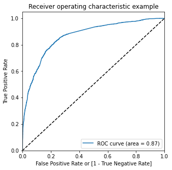

```python
# Call the ROC function
draw_roc(y_train_pred_final.Converted, y_train_pred_final.Convert_Prob)
```

___The area under ROC curve is 0.87 which is a very good value.___

```python
# Creating columns with different probability cutoffs
numbers = [float(x)/10 for x in range(10)]
for i in numbers:
    y_train_pred_final[i]= y_train_pred_final.Convert_Prob.map(lambda x: 1 if x > i else 0)

y_train_pred_final.head()
```

|  | Converted | Convert_Prob | Predicted | 0.0 | 0.1 | 0.2 | 0.3 | 0.4 | 0.5 | 0.6 | 0.7 | 0.8 | 0.9 |
| --- | --- | --- | --- | --- | --- | --- | --- | --- | --- | --- | --- | --- | --- |
| 0 | 0 | 0.125434 | 0 | 1 | 1 | 0 | 0 | 0 | 0 | 0 | 0 | 0 | 0 |
| 1 | 1 | 0.477172 | 0 | 1 | 1 | 1 | 1 | 1 | 0 | 0 | 0 | 0 | 0 |
| 2 | 1 | 0.980999 | 1 | 1 | 1 | 1 | 1 | 1 | 1 | 1 | 1 | 1 | 1 |
| 3 | 0 | 0.117742 | 0 | 1 | 1 | 0 | 0 | 0 | 0 | 0 | 0 | 0 | 0 |
| 4 | 1 | 0.221307 | 0 | 1 | 1 | 1 | 0 | 0 | 0 | 0 | 0 | 0 | 0 |

```python
# Creating a dataframe to see the values of accuracy, sensitivity, and specificity at different values of probabiity cutoffs
cutoff_df = pd.DataFrame( columns = ['prob','accuracy','sensi','speci'])
# Making confusing matrix to find values of sensitivity, accurace and specificity for each level of probablity
from sklearn.metrics import confusion_matrix
num = [0.0,0.1,0.2,0.3,0.4,0.5,0.6,0.7,0.8,0.9]
for i in num:
    cm1 = metrics.confusion_matrix(y_train_pred_final.Converted, y_train_pred_final[i] )
    total1=sum(sum(cm1))
    accuracy = (cm1[0,0]+cm1[1,1])/total1

    speci = cm1[0,0]/(cm1[0,0]+cm1[0,1])
    sensi = cm1[1,1]/(cm1[1,0]+cm1[1,1])
    cutoff_df.loc[i] =[ i ,accuracy,sensi,speci]
cutoff_df
```

|  | prob | accuracy | sensi | speci |
| --- | --- | --- | --- | --- |
| 0.0 | 0.0 | 0.375061 | 1.000000 | 0.000000 |
| 0.1 | 0.1 | 0.541485 | 0.970677 | 0.283903 |
| 0.2 | 0.2 | 0.764354 | 0.874084 | 0.698499 |
| 0.3 | 0.3 | 0.788129 | 0.827081 | 0.764752 |
| 0.4 | 0.4 | 0.803655 | 0.747736 | 0.837215 |
| 0.5 | 0.5 | 0.789099 | 0.621389 | 0.889752 |
| 0.6 | 0.6 | 0.784409 | 0.552824 | 0.923395 |
| 0.7 | 0.7 | 0.771955 | 0.479086 | 0.947723 |
| 0.8 | 0.8 | 0.742358 | 0.358344 | 0.972826 |
| 0.9 | 0.9 | 0.710173 | 0.245364 | 0.989130 |

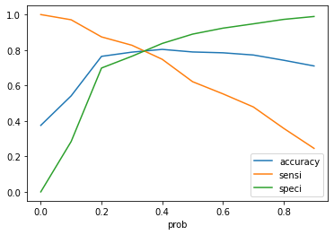

```python
# Plotting it
cutoff_df.plot.line(x='prob', y=['accuracy','sensi','speci'])
plt.show()
```

___From the graph it is visible that the optimal cut off is at 0.35.___

```python
y_train_pred_final['final_predicted'] = y_train_pred_final.Convert_Prob.map( lambda x: 1 if x > 0.35 else 0)
y_train_pred_final.head()
```

|  | Converted | Convert_Prob | Predicted | 0.0 | 0.1 | 0.2 | 0.3 | 0.4 | 0.5 | 0.6 | 0.7 | 0.8 | 0.9 | final_predicted |
| --- | --- | --- | --- | --- | --- | --- | --- | --- | --- | --- | --- | --- | --- | --- |
| 0 | 0 | 0.125434 | 0 | 1 | 1 | 0 | 0 | 0 | 0 | 0 | 0 | 0 | 0 | 0 |
| 1 | 1 | 0.477172 | 0 | 1 | 1 | 1 | 1 | 1 | 0 | 0 | 0 | 0 | 0 | 1 |
| 2 | 1 | 0.980999 | 1 | 1 | 1 | 1 | 1 | 1 | 1 | 1 | 1 | 1 | 1 | 1 |
| 3 | 0 | 0.117742 | 0 | 1 | 1 | 0 | 0 | 0 | 0 | 0 | 0 | 0 | 0 | 0 |
| 4 | 1 | 0.221307 | 0 | 1 | 1 | 1 | 0 | 0 | 0 | 0 | 0 | 0 | 0 | 0 |

```python
# Check the overall accuracy
metrics.accuracy_score(y_train_pred_final.Converted, y_train_pred_final.final_predicted)
```

```
0.7960536956170144
```

```python
# Creating confusion matrix
confusion2 = metrics.confusion_matrix(y_train_pred_final.Converted, y_train_pred_final.final_predicted )
confusion2
```

```
array([[3102,  762],
       [ 499, 1820]], dtype=int64)
```

```python
# Substituting the value of true positive
TP = confusion2[1,1]
# Substituting the value of true negatives
TN = confusion2[0,0]
# Substituting the value of false positives
FP = confusion2[0,1]
# Substituting the value of false negatives
FN = confusion2[1,0]
```

```python
# Calculating the sensitivity
TP/(TP+FN)
```

```
0.7848210435532557
```

```python
# Calculating the specificity
TN/(TN+FP)
```

```
0.8027950310559007
```

## 9. Precision-Recall

```python
confusion = metrics.confusion_matrix(y_train_pred_final.Converted, y_train_pred_final.Predicted)
confusion
```

```
array([[3759,  105],
       [1488,  831]], dtype=int64)
```

```python
# Precision = TP / TP + FP
confusion[1,1]/(confusion[0,1]+confusion[1,1])
```

```
0.8878205128205128
```

```python
#Recall = TP / TP + FN
confusion[1,1]/(confusion[1,0]+confusion[1,1])
```

```
0.35834411384217335
```

### 9.1. Precision and recall tradeoff

```python
from sklearn.metrics import precision_recall_curve
```

```python
y_train_pred_final.Converted, y_train_pred_final.Predicted
```

```
(0       0
 1       1
 2       1
 3       0
 4       1
        ..
 6178    0
 6179    0
 6180    0
 6181    0
 6182    1
 Name: Converted, Length: 6183, dtype: int64,
 0       0
 1       0
 2       1
 3       0
 4       0
        ..
 6178    0
 6179    0
 6180    0
 6181    0
 6182    0
 Name: Predicted, Length: 6183, dtype: int64)
```

```python
p, r, thresholds = precision_recall_curve(y_train_pred_final.Converted, y_train_pred_final.Convert_Prob)
```

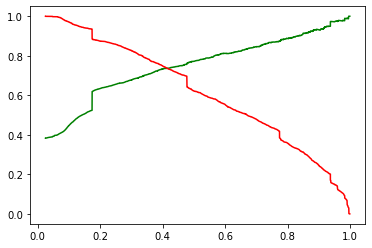

```python
plt.plot(thresholds, p[:-1], "g-")
plt.plot(thresholds, r[:-1], "r-")
plt.show()
```

```python
y_train_pred_final['final_predicted'] = y_train_pred_final.Convert_Prob.map(lambda x: 1 if x > 0.40 else 0)
y_train_pred_final.head()
```

|  | Converted | Convert_Prob | Predicted | 0.0 | 0.1 | 0.2 | 0.3 | 0.4 | 0.5 | 0.6 | 0.7 | 0.8 | 0.9 | final_predicted |
| --- | --- | --- | --- | --- | --- | --- | --- | --- | --- | --- | --- | --- | --- | --- |
| 0 | 0 | 0.125434 | 0 | 1 | 1 | 0 | 0 | 0 | 0 | 0 | 0 | 0 | 0 | 0 |
| 1 | 1 | 0.477172 | 0 | 1 | 1 | 1 | 1 | 1 | 0 | 0 | 0 | 0 | 0 | 1 |
| 2 | 1 | 0.980999 | 1 | 1 | 1 | 1 | 1 | 1 | 1 | 1 | 1 | 1 | 1 | 1 |
| 3 | 0 | 0.117742 | 0 | 1 | 1 | 0 | 0 | 0 | 0 | 0 | 0 | 0 | 0 | 0 |
| 4 | 1 | 0.221307 | 0 | 1 | 1 | 1 | 0 | 0 | 0 | 0 | 0 | 0 | 0 | 0 |

```python
# Accuracy
metrics.accuracy_score(y_train_pred_final.Converted, y_train_pred_final.final_predicted)
```

```
0.8036551835678474
```

```python
# Creating confusion matrix again
confusion2 = metrics.confusion_matrix(y_train_pred_final.Converted, y_train_pred_final.final_predicted )
confusion2
```

```
array([[3235,  629],
       [ 585, 1734]], dtype=int64)
```

```python
# Substituting the value of true positive
TP = confusion2[1,1]
# Substituting the value of true negatives
TN = confusion2[0,0]
# Substituting the value of false positives
FP = confusion2[0,1]
# Substituting the value of false negatives
FN = confusion2[1,0]
```

```python
# Precision = TP / TP + FP
TP / (TP + FP)
```

```
0.7338129496402878
```

```python
#Recall = TP / TP + FN
TP / (TP + FN)
```

```
0.7477360931435963
```

## Step 10: Making predictions on the test set

```python
X_test[['TotalVisits', 'Page Views Per Visit', 'Total Time Spent on Website']] = scaler.transform(X_test[['TotalVisits', 'Page Views Per Visit', 'Total Time Spent on Website']])
```

```python
col = X_train.columns
X_test = X_test[col]
X_test.head()
```

|  | Total Time Spent on Website | Lead Origin_lead add form | Lead Source_direct traffic | Lead Source_google | Lead Source_organic search | Lead Source_referral sites | Lead Source_welingak website | Do Not Email_yes | Last Activity_had a phone conversation | Last Activity_sms sent | What is your current occupation_working professional | Last Notable Activity_olark chat conversation | Last Notable Activity_unreachable |
| --- | --- | --- | --- | --- | --- | --- | --- | --- | --- | --- | --- | --- | --- |
| 4216 | 0.000000 | 1 | 0 | 0 | 0 | 0 | 0 | 0 | 0 | 0 | 0 | 0 | 0 |
| 4311 | 0.145890 | 0 | 0 | 0 | 1 | 0 | 0 | 0 | 0 | 0 | 0 | 0 | 0 |
| 3209 | 0.480675 | 0 | 0 | 1 | 0 | 0 | 0 | 0 | 0 | 1 | 0 | 0 | 0 |
| 1305 | 0.608057 | 0 | 0 | 1 | 0 | 0 | 0 | 0 | 0 | 0 | 1 | 0 | 0 |
| 2143 | 0.004355 | 0 | 0 | 1 | 0 | 0 | 0 | 0 | 0 | 1 | 0 | 0 | 0 |

```python
X_test_sm = sm.add_constant(X_test)
```

Making predictions on the test set

```python
y_test_pred = res.predict(X_test_sm)
```

```python
y_test_pred[:10]
```

```
4216    0.774091
4311    0.121012
3209    0.711129
1305    0.939281
2143    0.279683
423     0.156121
5867    0.173632
1481    0.952972
3943    0.173632
1280    0.046875
dtype: float64
```

```python
# Converting y_pred to a dataframe which is an array
y_pred_1 = pd.DataFrame(y_test_pred)
```

```python
# Let's see the head
y_pred_1.head()
```

|  | 0 |
| --- | --- |
| 4216 | 0.774091 |
| 4311 | 0.121012 |
| 3209 | 0.711129 |
| 1305 | 0.939281 |
| 2143 | 0.279683 |

```python
# Converting y_test to dataframe
y_test_df = pd.DataFrame(y_test)
```

```python
# Putting CustID to index
y_test_df['Index_ID'] = y_test_df.index
```

```python
# Removing index for both dataframes to append them side by side
y_pred_1.reset_index(drop=True, inplace=True)
y_test_df.reset_index(drop=True, inplace=True)
```

```python
# Appending y_test_df and y_pred_1
y_pred_final = pd.concat([y_test_df, y_pred_1],axis=1)
```

```python
y_pred_final.head()
```

|  | Converted | Index_ID | 0 |
| --- | --- | --- | --- |
| 0 | 1 | 4216 | 0.774091 |
| 1 | 0 | 4311 | 0.121012 |
| 2 | 1 | 3209 | 0.711129 |
| 3 | 1 | 1305 | 0.939281 |
| 4 | 0 | 2143 | 0.279683 |

```python
# Renaming the column
y_pred_final= y_pred_final.rename(columns={ 0 : 'Convert_Prob'})
```

```python
# Rearranging the columns
y_pred_final = y_pred_final.reindex(['Index_ID','Converted','Convert_Prob'], axis=1)
```

```python
# Let's see the head of y_pred_final
y_pred_final.head()
```

|  | Index_ID | Converted | Convert_Prob |
| --- | --- | --- | --- |
| 0 | 4216 | 1 | 0.774091 |
| 1 | 4311 | 0 | 0.121012 |
| 2 | 3209 | 1 | 0.711129 |
| 3 | 1305 | 1 | 0.939281 |
| 4 | 2143 | 0 | 0.279683 |

```python
y_pred_final['final_predicted'] = y_pred_final.Convert_Prob.map(lambda x: 1 if x > 0.35 else 0)
```

```python
y_pred_final.shape
```

```
(2651, 4)
```

```python
y_pred_final.head()
```

|  | Index_ID | Converted | Convert_Prob | final_predicted |
| --- | --- | --- | --- | --- |
| 0 | 4216 | 1 | 0.774091 | 1 |
| 1 | 4311 | 0 | 0.121012 | 0 |
| 2 | 3209 | 1 | 0.711129 | 1 |
| 3 | 1305 | 1 | 0.939281 | 1 |
| 4 | 2143 | 0 | 0.279683 | 0 |

```python
# Let's check the overall accuracy.
metrics.accuracy_score(y_pred_final.Converted, y_pred_final.final_predicted)
```

```
0.8159185213127121
```

```python
#Creating confusion Matrix
confusion2 = metrics.confusion_matrix(y_pred_final.Converted, y_pred_final.final_predicted )
confusion2
```

```
array([[1366,  295],
       [ 193,  797]], dtype=int64)
```

```python
# Let's see the sensitivity of our logistic regression model
TP / float(TP+FN)
```

```
0.7477360931435963
```

```python
# Let us calculate specificity
TN / float(TN+FP)
```

```
0.8372153209109731
```

```python
lead_df_copy=lead_df.copy()
lead_df_copy['Index_ID']=lead_df_copy.index
```

```python
final_lead = pd.merge(lead_df_copy[['Lead Number','Index_ID']], y_pred_final, on = 'Index_ID')
final_lead.head()
```

|  | Lead Number | Index_ID | Converted | Convert_Prob | final_predicted |
| --- | --- | --- | --- | --- | --- |
| 0 | 660680 | 5 | 0 | 0.173632 | 0 |
| 1 | 660624 | 8 | 0 | 0.069497 | 0 |
| 2 | 660534 | 17 | 0 | 0.353788 | 1 |
| 3 | 660522 | 18 | 1 | 0.756080 | 1 |
| 4 | 660471 | 22 | 1 | 0.427159 | 1 |

```python
final_lead['lead score']=round(final_lead.Convert_Prob*100,0)
```

```python
final_lead[final_lead.final_predicted==1]
```

|  | Lead Number | Index_ID | Converted | Convert_Prob | final_predicted | lead score |
| --- | --- | --- | --- | --- | --- | --- |
| 2 | 660534 | 17 | 0 | 0.353788 | 1 | 35.0 |
| 3 | 660522 | 18 | 1 | 0.756080 | 1 | 76.0 |
| 4 | 660471 | 22 | 1 | 0.427159 | 1 | 43.0 |
| 6 | 660447 | 25 | 1 | 0.455776 | 1 | 46.0 |
| 7 | 660432 | 26 | 1 | 0.392262 | 1 | 39.0 |
| ... | ... | ... | ... | ... | ... | ... |
| 2641 | 579869 | 9206 | 0 | 0.859590 | 1 | 86.0 |
| 2644 | 579808 | 9214 | 1 | 0.685622 | 1 | 69.0 |
| 2645 | 579778 | 9219 | 1 | 0.952588 | 1 | 95.0 |
| 2648 | 579712 | 9229 | 1 | 0.818756 | 1 | 82.0 |
| 2649 | 579622 | 9233 | 1 | 0.845334 | 1 | 85.0 |

1092 rows × 6 columns

```python
len(final_lead[final_lead.Converted == 1])/len(final_lead[final_lead.final_predicted == 1])
```

```
0.9065934065934066
```

# **Summary**

- **The conclusion of this report, the X Education company has to focus mostly on the following variable to achieve the 80% lead conversion rate toward their company. These variables are very potential to understand the customer profile and weather that customer potentially will buy the courses from the company or not. It is, therefore, the variables are:**
- **1. Total time Spent on website.**
- **2. Whenever the Lead Origin was:**

  ```
                             2.1. Add format
  ```

- **3. Whenever the Lead Source was:**

  ```
                             3.1. Direct Traffic
                             3.2. Google
                             3.3. Organic Search
                             3.4. Referral Sites
                             3.5. Welingak Website
  ```

- **4. When last notable activity:**

  ```
                             4.1. Olark Chat Conversation
                             4.2. Unreachable
  ```

- **5. When the email does not send yes.**
- **6. When the Last Activity:**

  ```
                             6.1 Had a Phone Conversation
                             6.2 SMS Sent
  ```

- **7. When the customer current occupation is working professional.**